# project_bio_p3.1

amirhosein

## Including Plots

Here for create UPGMA and NJ tree we use phangorn package, We have the data in csv format from the last part. for using diist function, we duplicate first row in our data.

Here you van find a describe of UPGMA and NJ: (for describe the algorithms I used Wikipedia and sequentix.de and megasoftware.net)

UPGMA: · UPGMA starts with a matrix of pairwise distances D[1..n, 1..m]. · In the following text each sample (taxon, operational taxonomic unit=OTU) is denoted as a ‘cluster’. · starts by assigning all clusters (samples) to a star-like tree

1. Find that pair (cluster i and j) with the smallest distance value in the distance matrix: D[i,j].
2. Define a new cluster comprising cluster i and j: Cluster i is connected by a branch to the common ancestor node. The same applies for cluster j. Therefore, the distance D[i,j] is split onto the two branches. So, each of the two branches obtains a length of D[i,j]/2.
3. If i and j were the last 2 clusters, the tree is finished. If not the algorithm finds a new cluster called u.
4. Define the distance from u to each other cluster (k, with k <> i or j) to be an average of the distances dki and dkj. For ‘Weighted PGMA (WPGM)’: dku = dki+dkj/2). For ‘Complete linkage’: dku = max(dki, dkj). For ‘Single linkage’: dku = min(dki, dkj).
5. Go back to step 1 with one less cluster. Clusters i and j are eliminated, and cluster u is added to the tree.

NJ: The NJ method is a simplified version of the minimum evolution (ME) method, which uses distance measures to correct for multiple hits at the same sites, and chooses a topology showing the smallest value of the sum of all branches as an estimate of the correct tree. However, the construction of an ME tree is time-consuming because, in principle, the S values for all topologies have to be evaluated and the number of possible topologies (unrooted trees) rapidly increases with the number of taxa.

With the NJ method, the S value is not computed for all or many topologies. The examination of different topologies is imbedded in the algorithm, so that only one final tree is produced. This method does not require the assumption of a constant rate of evolution so it produces an unrooted tree. However, for ease of inspection, MEGA displays NJ trees in a manner similar to rooted trees. The algorithm of the NJ method is somewhat complicated and is explained in detail in Nei and Kumar (2000).

For constructing the NJ tree, MEGA may request that you specify the distance estimation method, subset of sites to include, and whether to conduct a test of the inferred tree through an Analysis Preferences dialog box.

for L Gene, first is UPGMA and second is NG:

```r
library("phangorn")
mydata = read.csv(file="L.csv", header=TRUE, sep=",")
mydata
```

```
##     X1   X2   X3   X4   X5
## 1    0 2220 2440 1982 2444
## 2 2220    0 2407 2207 2415
## 3 2440 2407    0 2452 2475
## 4 1982 2207 2452    0 2439
## 5 2444 2415 2475 2439    0
```

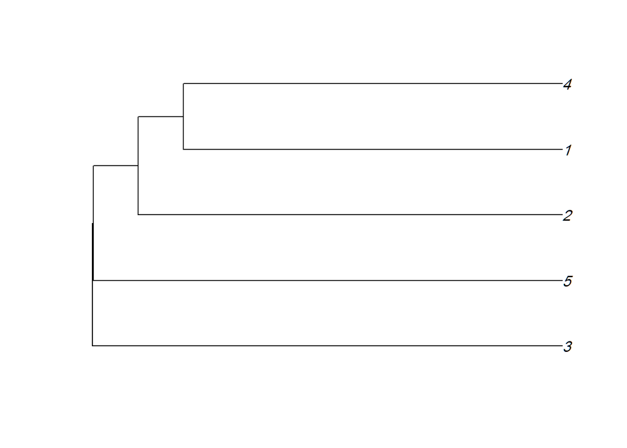

```r
mydata = dist(mydata)

tree = upgma(mydata)
plot(tree)
```

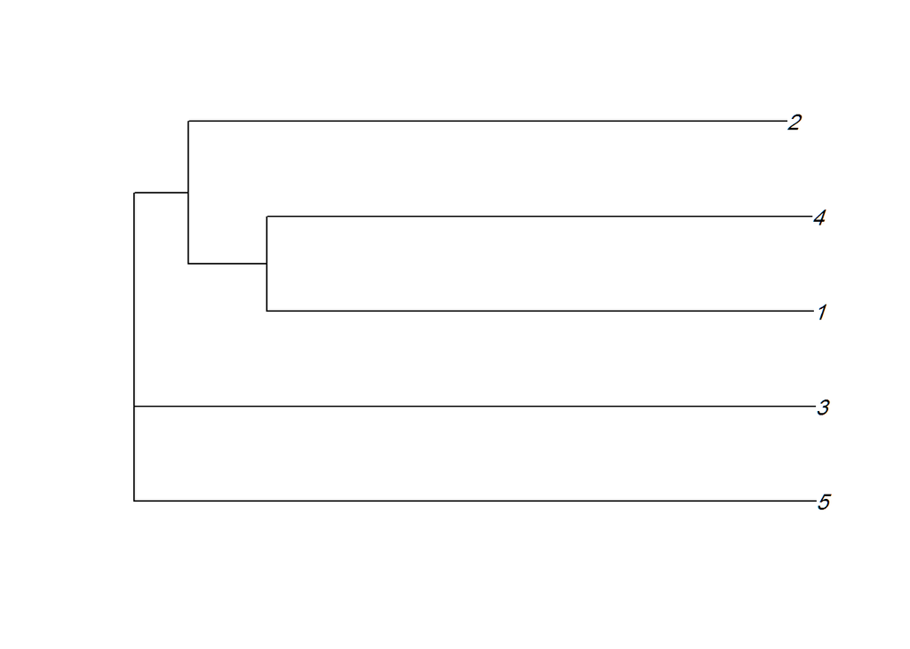

```r
tree = nj(mydata)
plot(tree)
```

for VP24 Gene, first is UOGMA and second is NG:

```r
library("phangorn")

mydata = read.csv(file="VP24.csv", header=TRUE, sep=",")
mydata
```

```
##    X0 X497 X542 X470 X548
## 1   0  497  542  470  548
## 2 497    0  545  507  551
## 3 542  545    0  549  553
## 4 470  507  549    0  565
## 5 548  551  553  565    0
```

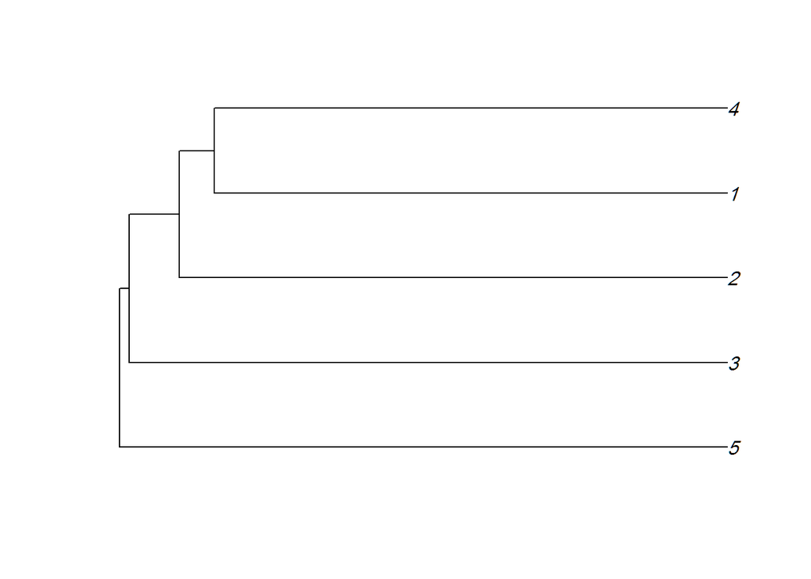

```r
mydata = dist(mydata)

tree = upgma(mydata)
plot(tree)
```

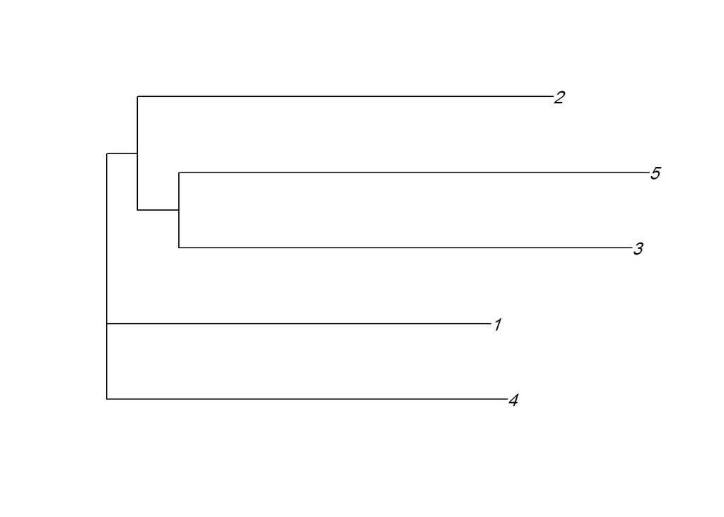

```r
tree = nj(mydata)
plot(tree)
```

for GP Gene, first is UOGMA and second is NG:

```r
library("phangorn")

mydata = read.csv(file="GP.csv", header=TRUE, sep=",")
mydata
```

```
##     X0 X1487 X1140 X953 X1162
## 1    0  1487  1140  953  1162
## 2 1487     0  1513 1527  1525
## 3 1140  1513     0 1151  1137
## 4  953  1527  1151    0  1095
## 5 1162  1525  1137 1095     0
```

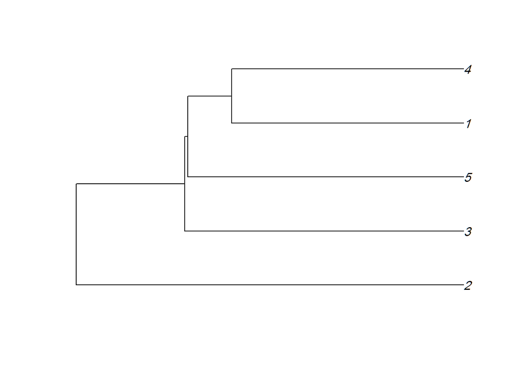

```r
mydata = dist(mydata)

tree = upgma(mydata)
plot(tree)
```

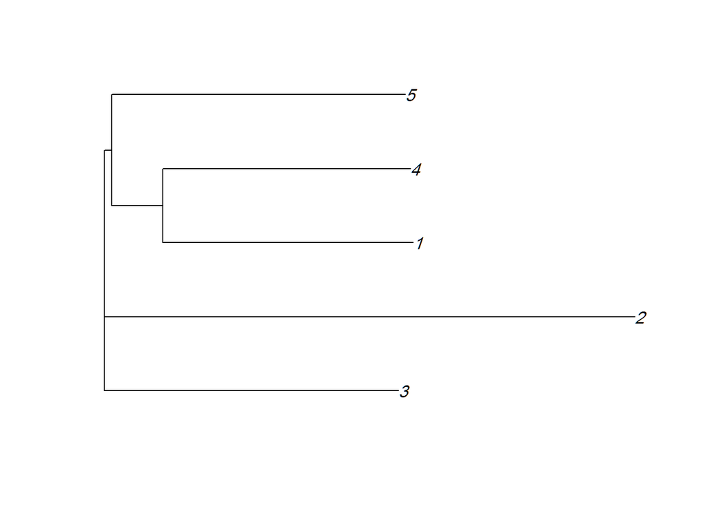

```r
tree = nj(mydata)
plot(tree)
```

for VP40 Gene, first is UOGMA and second is NG:

```r
library("phangorn")

mydata = read.csv(file="VP40.csv", header=TRUE, sep=",")
mydata
```

```
##    X0 X728 X743 X774 X715
## 1   0  728  743  774  715
## 2 728    0  567  790  537
## 3 743  567    0  784  529
## 4 774  790  784    0  793
## 5 715  537  529  793    0
```

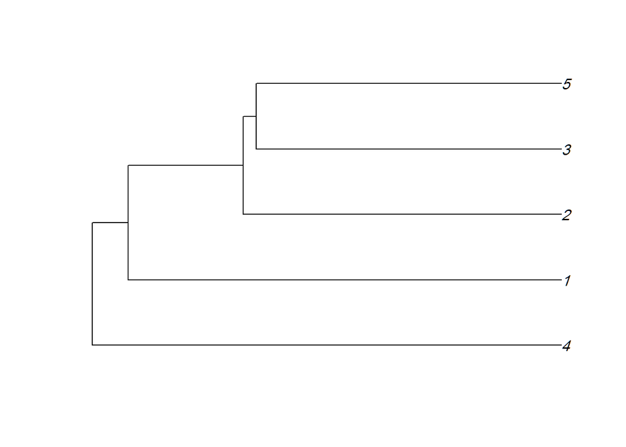

```r
mydata = dist(mydata)

tree = upgma(mydata)
plot(tree)
```

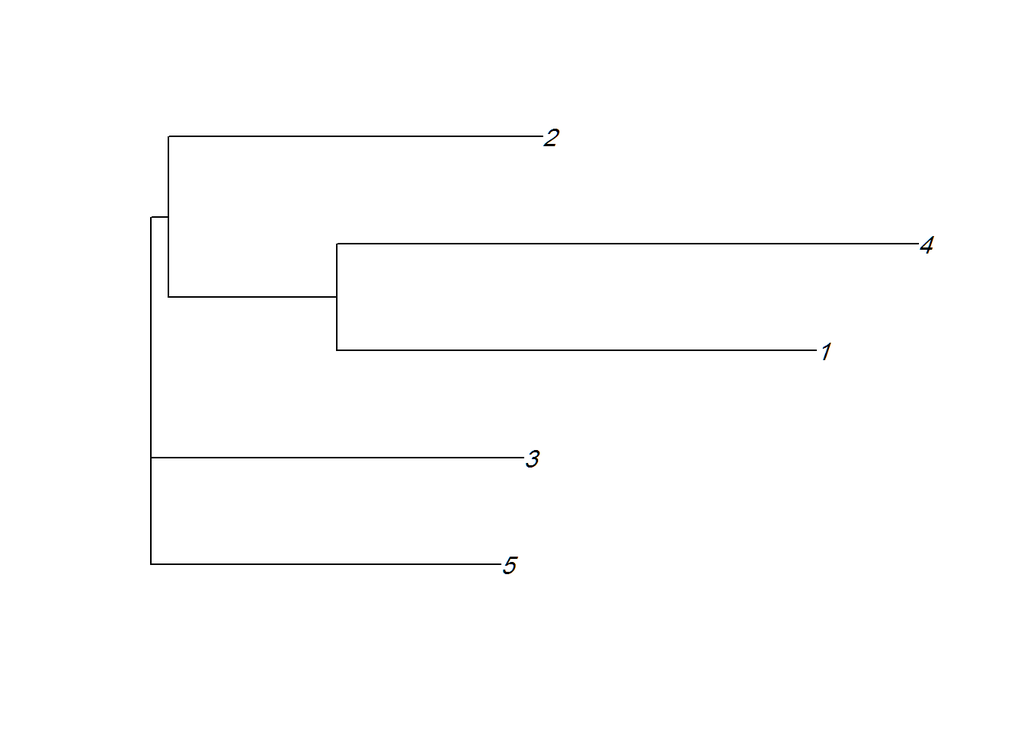

```r
tree = nj(mydata)
plot(tree)
```

for VP35 Gene, first is UOGMA and second is NG:

```r
library("phangorn")

mydata = read.csv(file="VP35.csv", header=TRUE, sep=",")
mydata
```

```
##    X0 X622 X690 X612 X681
## 1   0  622  690  612  681
## 2 622    0  602  585  612
## 3 690  602    0  607  612
## 4 612  585  607    0  645
## 5 681  612  612  645    0
```

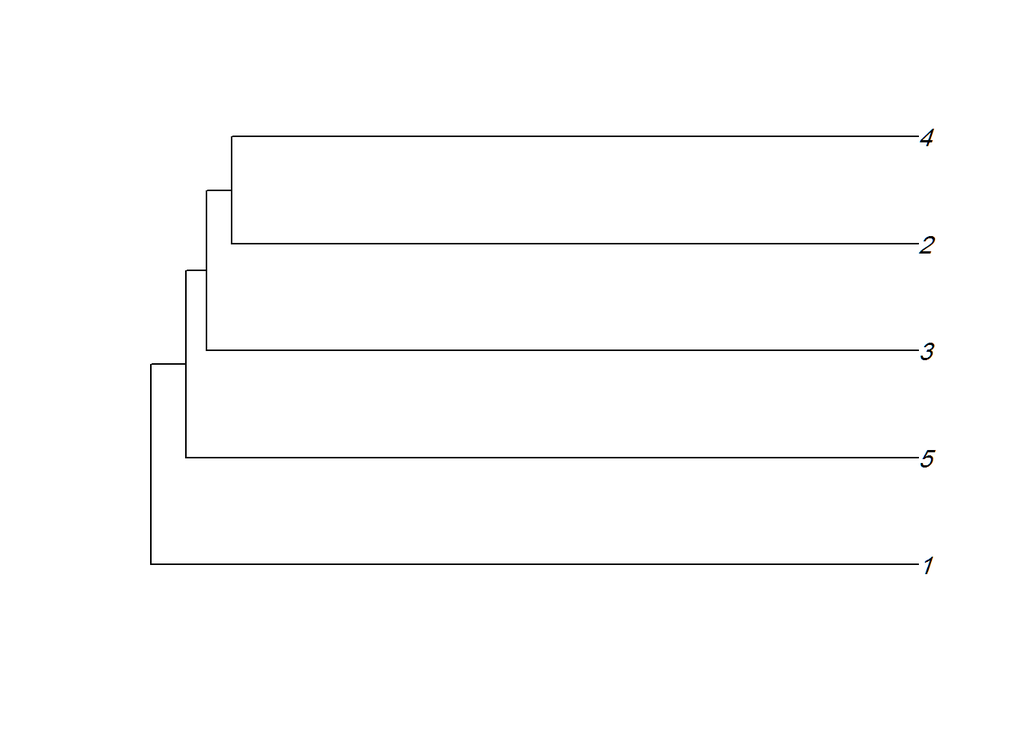

```r
mydata = dist(mydata)

tree = upgma(mydata)
plot(tree)
```

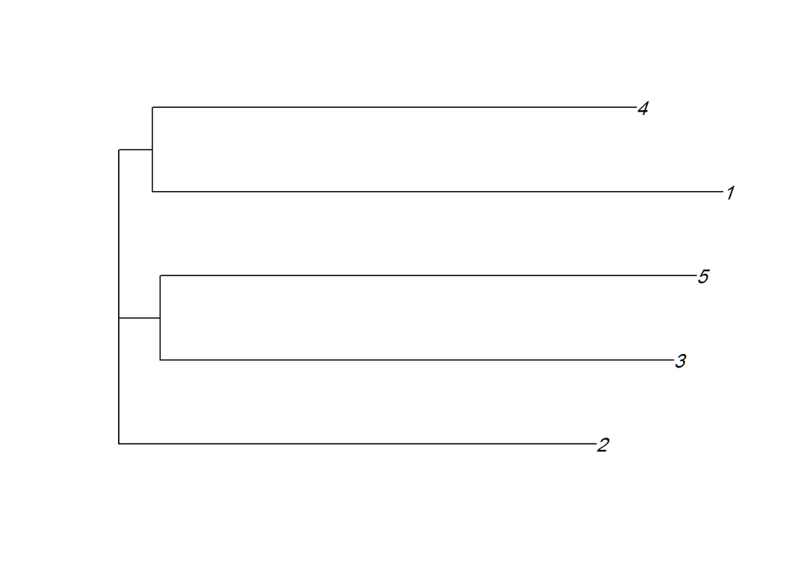

```r
tree = nj(mydata)
plot(tree)
```

for VP30 Gene, first is UOGMA and second is NG:

```r
library("phangorn")

mydata = read.csv(file="VP30.csv", header=TRUE, sep=",")

mydata = dist(mydata)

mydata
```

```
##           1         2         3         4
## 2  694.3803
## 3  763.8567  714.4641
## 4 1000.2750  969.4720  987.0841
## 5  749.3350  653.9656  749.6212  967.3888
```

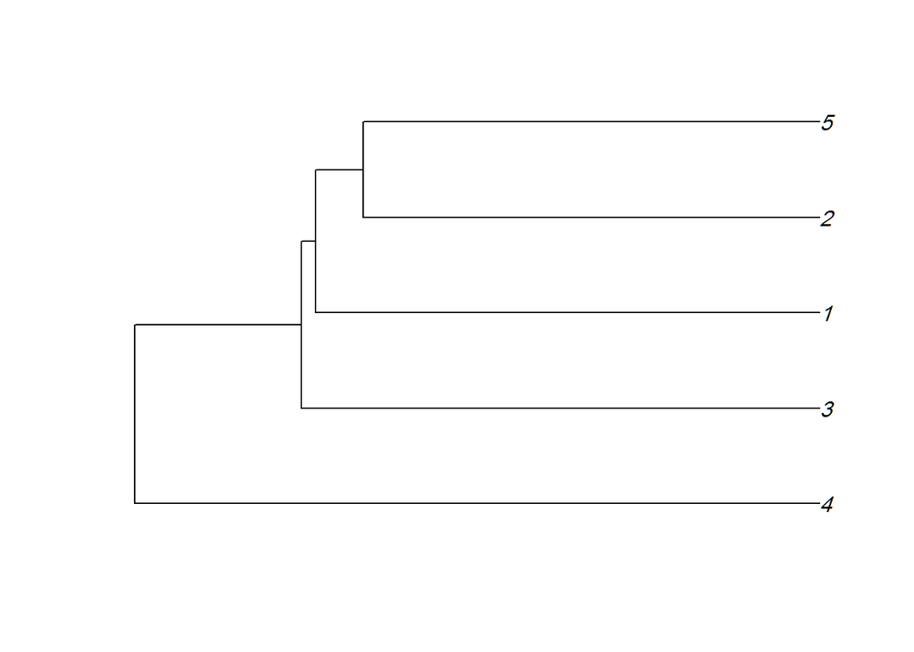

```r
tree = upgma(mydata)
plot(tree)
```

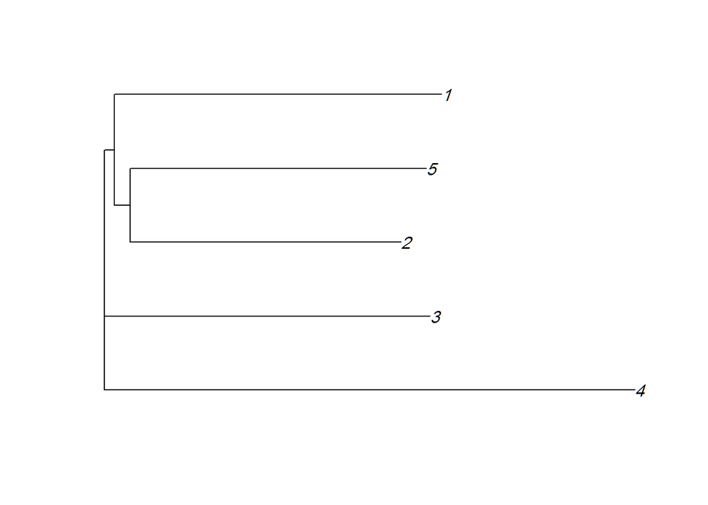

```r
tree = nj(mydata)
plot(tree)
```

for NP Gene, first is UOGMA and second is NG:

```r
library("phangorn")

mydata = read.csv(file="NP.csv", header=TRUE, sep=",")
mydata
```

```
##     X0 X956 X1005 X880 X1114
## 1    0  956  1005  880  1114
## 2  956    0  1007  953  1058
## 3 1005 1007     0 1063  1074
## 4  880  953  1063    0  1076
## 5 1114 1058  1074 1076     0
```

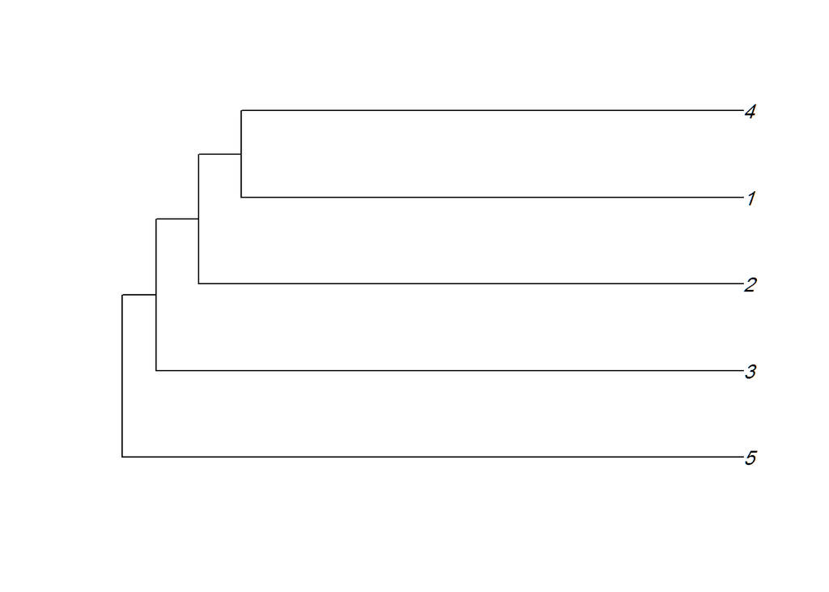

```r
mydata = dist(mydata)

tree = upgma(mydata)
plot(tree)
```

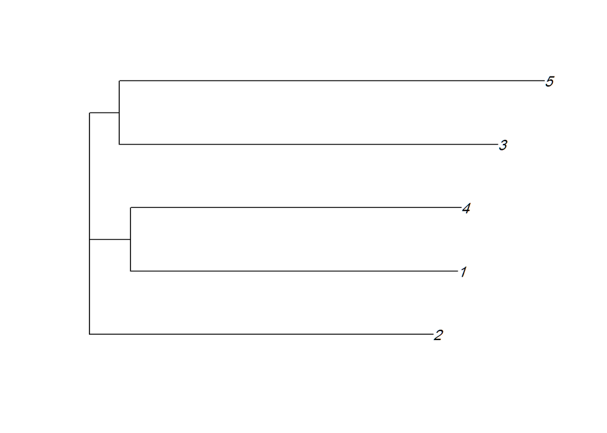

```r
tree = nj(mydata)
plot(tree)
```